# Manipulation Pretest: Analyses & Results

Matteo Lisi

2024-05-20

# Load & prepare data

## R session

Libraries used for this report:

```r
library(tidyverse)
library(qualtRics)
library(sjPlot)
library(ordinal)
library(lme4)
library(patchwork)
```

## Dataset

Please note that the data in `manip_test_noOverlap_anonim.csv` have been already anonymised (`PROLIFIC_PID` has been replaced with an anonymous code) and do not contain the participants that also participated in the reading pre-test.

```r
d <- read_csv("./manip_test_noOverlap_anonim.csv")
```

### Experimental conditions

The three conditions in this experiment are the following

- **CG**: Control Group
- **BJ**: Baseline Justification (standard wording for response justification)
- **IJ**: Improved Justification (enhanced wording for response justification)

## Completion rates

To compute the completion rates, previews have been excluded. The group (condition) assignment was determined from the first click in the practice trial.

```r
dropout_rates <- d %>%
  filter(Status == 0) %>%
  mutate(group = case_when(
    !is.na(`practice_CG_task_rt_First Click`) ~ "CG",
    !is.na(`practice_BJ_task_rt_First Click`) ~ "BJ",
    !is.na(`practice_IJ_task_rt_First Click`) ~ "IJ",
    .default = NA
  )) %>%
  group_by(PROLIFIC_PID, group) %>%
  summarise(Completed = max(Finished == 1)) %>%
  ungroup() %>%
  group_by(group) %>%
  summarise(
    Total_Participants = n(),
    Dropouts = sum(Completed == 0),
    Dropout_Rate = Dropouts / Total_Participants
  )

print(dropout_rates)
```

```
## # A tibble: 4 × 4
##   group Total_Participants Dropouts Dropout_Rate
##   <chr>              <int>    <int>        <dbl>
## 1 BJ                   712       33      0.0463
## 2 CG                   711        7      0.00985
## 3 IJ                   712       34      0.0478
## 4 <NA>                  35       35      1
```

## Exclusions

The following table provides a breakdown of the number of participants excluded based on each criterion.

```r
total_initial <- nrow(d)

# Status == 0
excluded_status <- total_initial - nrow(d %>% filter(Status == 0))
remaining_after_status <- nrow(d %>% filter(Status == 0))


# Finished == 1
excluded_finished <- remaining_after_status - nrow(d %>% filter(Status == 0,
                                                                Finished == 1))
#excluded_finished <- total_initial - nrow(d %>% filter(Finished == 1))
remaining_after_finished <- nrow(d %>% filter(Status == 0,
                                              Finished == 1))

# Q_RecaptchaScore > 0.5
excluded_recaptcha <- remaining_after_finished - nrow(d %>% filter(Status == 0,
                                                                   Finished == 1,
                                                                   Progress >= 99,
                                                                   Q_RecaptchaScore >= 0.5))
remaining_after_recaptcha <- nrow(d %>% filter(Status == 0,
                                               Finished == 1,
                                               Progress >= 99,
                                               Q_RecaptchaScore >= 0.5))

# Total number of participants excluded (excluded because they fail at least 1 criterion)
total_excluded <- total_initial - remaining_after_recaptcha

# Create summary table
summary_table <- data.frame(
  Criterion = c( "Status == 0",
                 "Finished == 1",
                 "Q_RecaptchaScore >= 0.5",
                 "Total"),
  Excluded = c(excluded_status,
               excluded_finished,
               excluded_recaptcha,
               total_excluded),
  Fraction = c(excluded_status/total_initial,
               excluded_finished/total_initial,
               excluded_recaptcha/total_initial,
               total_excluded/total_initial),

  Percentage = c(excluded_status/total_initial * 100,
               excluded_finished/total_initial * 100,
               excluded_recaptcha/total_initial * 100,
               total_excluded/total_initial * 100)
)

# Print the summary table as an HTML table
kable(summary_table, format = "html", booktabs = TRUE,
      col.names = c("Exclusion Criterion", "Number Excluded", "Fraction Excluded", "Percentage Excluded"),
      caption="Each line indicate how many participants failed each criterion. Exclusion criteria are applied sequentially in order; the last line indicate how many participants failed at least one criterion in total.") %>%
  kable_styling(bootstrap_options = c("striped", "hover", "condensed"))
```

Each line indicate how many participants failed each criterion. Exclusion criteria are applied sequentially in order; the last line indicate how many participants failed at least one criterion in total.

| Exclusion Criterion | Number Excluded | Fraction Excluded | Percentage Excluded |
| --- | --- | --- | --- |
| Status == 0 | 3 | 0.0013705 | 0.1370489 |
| Finished == 1 | 123 | 0.0561900 | 5.6190041 |
| Q_RecaptchaScore >= 0.5 | 25 | 0.0114207 | 1.1420740 |
| Total | 151 | 0.0689813 | 6.8981270 |

Remove participants who failed at least one of the above criteria.

```r
d <- d %>%
  filter(Consent == 1,
         Progress >= 99,
         Finished == 1,
         Status == 0,
         Q_RecaptchaScore >= 0.5)
```

Check for duplicated responses (same Prolific ID with more than one response):

```r
n_pid <- tapply(d$PROLIFIC_PID, d$PROLIFIC_PID, length)
length(n_pid[n_pid==2])
```

```
## [1] 2
```

These participants completed the survey twice:

```r
duplicate_id <- names(n_pid[n_pid==2])
duplicate_id
```

```
## [1] "mc493" "mc589"
```

To ensure data quality, only the first response (based on response date and time) for each duplicate ID will be included in the analysis:

```r
# keep in only the first response for each duplicate
duplicates <- d %>%
  filter(PROLIFIC_PID %in% duplicate_id) %>%
  arrange(PROLIFIC_PID, StartDate, EndDate) %>%
  group_by(PROLIFIC_PID) %>%
  dplyr::slice(1) %>% # slice operate on each group for grouped df
  ungroup()

# non-duplicate responses
non_duplicates <- d %>%
  filter(!PROLIFIC_PID %in% duplicate_id)

# put them back together
d <- bind_rows(duplicates, non_duplicates)
```

## Demographics information of participants

```r
demographic_summary <- d %>%
  summarise(
    `Avearge age (Std.)` = sprintf("%.2f (%.2f)", mean(Age, na.rm = TRUE), sd(Age, na.rm = TRUE)),
    `Age Range` = paste(min(Age, na.rm = TRUE), "to", max(Age, na.rm = TRUE)),
    `N. males` = sprintf("%i", sum(Sex == 0, na.rm = TRUE)),
    `N. female` = sprintf("%i", sum(Sex == 1, na.rm = TRUE))
  ) %>%
  pivot_longer(everything(), names_to = "Demographic", values_to = "Value")

knitr::kable(demographic_summary, format = "html", booktabs = TRUE, caption = "Demographic Information of Participants", col.names = c("Demographic", "Value"))%>%
  kable_styling(latex_options = c("scale_down","striped"))
```

Demographic Information of Participants

| Demographic | Value |
| --- | --- |
| Avearge age (Std.) | 42.86 (13.45) |
| Age Range | 18 to 94 |
| N. males | 958 |
| N. female | 1078 |

## Data Transformation

To prepare the data for analysis, we transform it into a long format. This is done separately for each condition (CG, BJ, and IJ) and then combined.

```r
# CG
crt_CG <- d %>% select(PROLIFIC_PID, matches("^crt[0-9]+_CG"))
crt_CG <- crt_CG %>%
  pivot_longer(
    cols = -PROLIFIC_PID,
    names_to = c("crt", ".value"),
    names_pattern = "(crt\\d+)_CG_(.*)")
crt_CG$group <- "CG"
crt_CG$explain <- NA

# BJ
crt_BJ <- d %>% select(PROLIFIC_PID, matches("^crt[0-9]+_BJ"))
crt_BJ <- crt_BJ %>%
  pivot_longer(
    cols = -PROLIFIC_PID,
    names_to = c("crt", ".value"),
    names_pattern = "(crt\\d+)_BJ_(.*)")
crt_BJ$group <- "BJ"

# IJ
crt_IJ <- d %>% select(PROLIFIC_PID, matches("^crt[0-9]+_IJ"))
crt_IJ <- crt_IJ %>%
  pivot_longer(
    cols = -PROLIFIC_PID,
    names_to = c("crt", ".value"),
    names_pattern = "(crt\\d+)_IJ_(.*)")
crt_IJ$group <- "IJ"

# put together
other_info <- d %>% select(PROLIFIC_PID, !matches("^crt[0-9]")) %>%
  select(PROLIFIC_PID, !starts_with("practice"))
crt_all <- rbind(crt_CG, crt_BJ, crt_IJ)
dat <- left_join(crt_all, other_info, by = "PROLIFIC_PID") %>%
  filter(!is.na(task))

# recode response accuracy as binary 0/1
dat$accuracy <- ifelse(!is.na(dat$task),
                       ifelse(dat$task==1,1,0),
                       dat$task)

# contrast coding for condition label
dat$group <- factor(dat$group)
contrasts(dat$group) <- contr.treatment(levels(dat$group), base=2)

# make a smaller dataset for analysis, with counts of
# correct and errors for each participant
dag <- dat %>%
  group_by(PROLIFIC_PID, group) %>%
  summarise(correct = sum(accuracy, na.rm=T),
            N = n(),
            accuracy=mean(accuracy, na.rm=T)) %>%
  mutate(errors = N-correct) %>%
  filter(!is.nan(accuracy))

# sanity check
all(dag$N==6)
```

```
## [1] TRUE
```

```r
# display 5 random IDs
dag[is.element(dag$PROLIFIC_PID,sample(dag$PROLIFIC_PID,5)),]
```

```
## # A tibble: 5 × 6
## # Groups:   PROLIFIC_PID [5]
##   PROLIFIC_PID group correct     N accuracy errors
##   <chr>        <fct>   <dbl> <int>    <dbl>  <dbl>
## 1 mc1068       BJ          4     6    0.667      2
## 2 mc1085       CG          6     6    1          0
## 3 mc2079       CG          3     6    0.5        3
## 4 mc810        BJ          4     6    0.667      2
## 5 mc963        IJ          4     6    0.667      2
```

## Summary statistics

```r
stat_summary <- dat %>%
  group_by(PROLIFIC_PID, group) %>%
  summarise(accuracy = mean(accuracy, na.rm = TRUE),
            RT = mean(`task_rt_Page Submit`, na.rm = TRUE)) %>%
  group_by(group)%>%
  summarise(
    Accuracy = sprintf("%.2f (%.2f)", mean(accuracy, na.rm = TRUE), sd(accuracy, na.rm = TRUE)),
    `Response time` = sprintf("%.2f (%.2f)", mean(RT, na.rm = TRUE), sd(RT, na.rm = TRUE))
  )

knitr::kable(stat_summary, format = "html", booktabs = TRUE, caption = "Summary statistics (accuracy and response time); values reported as mean (Std.) across participants.") %>%
  kable_styling(latex_options = c("scale_down","striped"))
```

Summary statistics (accuracy and response time); values reported as mean (Std.) across participants.

| group | Accuracy | Response time |
| --- | --- | --- |
| BJ | 0.61 (0.30) | 81.88 (53.82) |
| CG | 0.54 (0.29) | 25.84 (16.34) |
| IJ | 0.61 (0.31) | 89.09 (51.87) |

## Summary statistics by CRT problem

```r
stat_summary <- dat %>%
  group_by(crt, group) %>%
  summarise(
    Accuracy = sprintf("%.2f (%.2f)", mean(accuracy, na.rm = TRUE), sd(accuracy, na.rm = TRUE)),
    RT = sprintf("%.2f (%.2f)", mean(`task_rt_Page Submit`, na.rm = TRUE), sd(`task_rt_Page Submit`, na.rm = TRUE))
  )  %>%
  pivot_wider(
    names_from = group,
    values_from = c(Accuracy, RT),
    names_sep = " "
  )

knitr::kable(stat_summary, format = "html", booktabs = TRUE, caption = "Summary statistics of accuracy and response time for individual CRT problems")%>%
  kable_styling(latex_options = c("scale_down","striped"))
```

Summary statistics of accuracy and response time for individual CRT problems

| crt | Accuracy BJ | Accuracy CG | Accuracy IJ | RT BJ | RT CG | RT IJ |
| --- | --- | --- | --- | --- | --- | --- |
| crt1 | 0.69 (0.46) | 0.67 (0.47) | 0.64 (0.48) | 55.58 (43.22) | 17.37 (15.50) | 60.02 (44.46) |
| crt2 | 0.81 (0.39) | 0.75 (0.43) | 0.77 (0.42) | 47.21 (38.45) | 14.23 (12.21) | 54.39 (44.92) |
| crt3 | 0.46 (0.50) | 0.34 (0.47) | 0.49 (0.50) | 99.11 (105.86) | 32.17 (32.60) | 106.47 (79.94) |
| crt4 | 0.63 (0.48) | 0.63 (0.48) | 0.67 (0.47) | 100.47 (119.90) | 29.58 (29.44) | 107.26 (89.26) |
| crt5 | 0.57 (0.50) | 0.51 (0.50) | 0.60 (0.49) | 83.98 (75.97) | 29.88 (32.95) | 88.34 (69.37) |
| crt6 | 0.49 (0.50) | 0.36 (0.48) | 0.49 (0.50) | 104.93 (94.57) | 31.80 (30.18) | 118.08 (100.23) |

# Effect of response justification on accuracy

First, we recode the contrasts of condition (`group`) such that the control group is the baseline.

- `CG` control group
- `BJ` response justification
- `IJ` response justification with improved wording

```r
dag$group <- factor(dag$group)
contrasts(dag$group) <- contr.treatment(levels(dag$group), base=2)
contrasts(dag$group)
```

```
##    BJ IJ
## BJ  1  0
## CG  0  0
## IJ  0  1
```

Next, we compare the differences in accuracy between groups using logistic regression. A random effects model with random intercepts by participants and items is employed

```r
dag_acc <- dat %>%
  group_by(PROLIFIC_PID, group, crt) %>%
  summarise(accuracy=mean(accuracy, na.rm=T))

m_logi <- glmer(accuracy ~ group  + (1|PROLIFIC_PID) + (1|crt), family=binomial("logit"), data=dag_acc, control=glmerControl(optimizer="bobyqa"))

summary(m_logi)
```

```
## Generalized linear mixed model fit by maximum likelihood (Laplace
##   Approximation) [glmerMod]
##  Family: binomial  ( logit )
## Formula: accuracy ~ group + (1 | PROLIFIC_PID) + (1 | crt)
##    Data: dag_acc
## Control: glmerControl(optimizer = "bobyqa")
##
##      AIC      BIC   logLik deviance df.resid
##  14421.5  14458.5  -7205.7  14411.5    12211
##
## Scaled residuals:
##     Min      1Q  Median      3Q     Max
## -3.3500 -0.7094  0.3013  0.5935  2.6122
##
## Random effects:
##  Groups       Name        Variance Std.Dev.
##  PROLIFIC_PID (Intercept) 2.0463   1.4305
##  crt          (Intercept) 0.5339   0.7307
## Number of obs: 12216, groups:  PROLIFIC_PID, 2036; crt, 6
##
## Fixed effects:
##             Estimate Std. Error z value Pr(>|z|)
## (Intercept)  0.25945    0.30537   0.850    0.396
## groupBJ      0.39511    0.09482   4.167 3.09e-05 ***
## groupIJ      0.39273    0.09496   4.136 3.54e-05 ***
## ---
## Signif. codes:  0 '***' 0.001 '**' 0.01 '*' 0.05 '.' 0.1 ' ' 1
##
## Correlation of Fixed Effects:
##         (Intr) gropBJ
## groupBJ -0.150
## groupIJ -0.150  0.485
```

```r
tab_model(m_logi, show.icc=FALSE, show.r2 = FALSE)
```

|  | accuracy |  |  |
| --- | --- | --- | --- |
| Predictors | Odds Ratios | CI | p |
| (Intercept) | 1.30 | 0.71 – 2.36 | 0.396 |
| group [BJ] | 1.48 | 1.23 – 1.79 | **<0.001** |
| group [IJ] | 1.48 | 1.23 – 1.78 | **<0.001** |
| Random Effects |  |  |  |
| σ<sup>2</sup> | 3.29 |  |  |
| τ<sub>00</sub> <sub>PROLIFIC_PID</sub> | 2.05 |  |  |
| τ<sub>00</sub> <sub>crt</sub> | 0.53 |  |  |
| N <sub>PROLIFIC_PID</sub> | 2036 |  |  |
| N <sub>crt</sub> | 6 |  |  |
| Observations | 12216 |  |  |

### Standardized effect sizes

This gives the following:

```r
(fixef(m_logi)[2:3] * sqrt(3)) / pi
```

```
##   groupBJ   groupIJ
## 0.2178343 0.2165230
```

Perhaps a more straightforward approach could be simply to apply Cohen’s classical formula for the difference in mean accuracy and divide by the pooled standard deviations. This provides the following estimates, which are numerically very close to the previous ones.

```r
pooled_sd <- function(x, y) {
  nx <- length(x)
  ny <- length(y)
  sqrt(((nx - 1) * var(x) + (ny - 1) * var(y)) / (nx + ny - 2))
}

BJ <- dag$accuracy[dag$group=="BJ"]
IJ <- dag$accuracy[dag$group=="IJ"]
CG <- dag$accuracy[dag$group=="CG"]

# effect size for BJ vs CG
(mean(BJ) - mean(CG)) / pooled_sd(BJ, CG)
```

```
## [1] 0.2224753
```

```r
# effect size for IJ vs CG
(mean(IJ) - mean(CG)) / pooled_sd(IJ, CG)
```

```
## [1] 0.2161627
```

## Does the improved wording make a difference?

```r
contrasts(dag_acc$group) <- contr.treatment(levels(dag_acc$group), base=1)
m_logi2 <- glmer(accuracy ~ group  + (1|PROLIFIC_PID) + (1|crt), family=binomial("logit"), data=dag_acc, control=glmerControl(optimizer="bobyqa"))
tab_model(m_logi2, show.r2 = FALSE, show.icc=FALSE)
```

|  | accuracy |  |  |
| --- | --- | --- | --- |
| Predictors | Odds Ratios | CI | p |
| (Intercept) | 1.92 | 1.06 – 3.50 | **0.032** |
| group [CG] | 0.67 | 0.56 – 0.81 | **<0.001** |
| group [IJ] | 1.00 | 0.83 – 1.20 | 0.980 |
| Random Effects |  |  |  |
| σ<sup>2</sup> | 3.29 |  |  |
| τ<sub>00</sub> <sub>PROLIFIC_PID</sub> | 2.05 |  |  |
| τ<sub>00</sub> <sub>crt</sub> | 0.53 |  |  |
| N <sub>PROLIFIC_PID</sub> | 2036 |  |  |
| N <sub>crt</sub> | 6 |  |  |
| Observations | 12216 |  |  |

## Plot

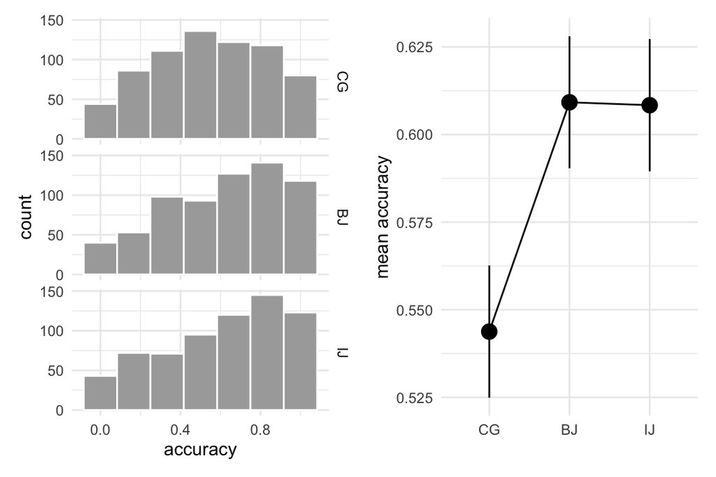

```r
# binomial standard error
binomSEM <- function(v){
  sqrt((mean(v) * (1 - mean(v)))/length(v))
  }

# compute average accuracy
dag2 <- aggregate(accuracy ~ group, dag, mean)
dag2$se <- aggregate(accuracy ~ group, dag, binomSEM)$accuracy

pl1 <- dag %>%
  ggplot(aes(x=accuracy)) +
  geom_histogram(binwidth=1/6, fill="darkgrey",color="white")+
  facet_grid(fct_relevel(group, "CG")~.)+
  theme_minimal()+
  labs(x="accuracy")

pl2 <- dag2 %>%
  ggplot(aes(x=fct_relevel(group, "CG"), y=accuracy)) +
  theme_minimal()+
  labs(x="", y="mean accuracy")+
  geom_point(size=4) +
  geom_errorbar(aes(ymin=accuracy-se, ymax=accuracy+se), width=0)+
  geom_line(aes(group=1))

pl1 + pl2
```

# Length of response justification

This section examines the content of the response justifications in terms of the raw number of characters and the number of words.

```r
dat %>%
  filter(group!="CG") %>%
  mutate(
    word_count = str_count(explain, "\\S+"), # Count words
    char_count = nchar(explain)  # Count characters
  ) %>%
  group_by(group) %>%
  summarise(
    `average word count (std.)` = sprintf("%.2f (%.2f)", mean(word_count, na.rm = TRUE), sd(word_count, na.rm = TRUE)),
    `average char. count (std.)` = sprintf("%.2f (%.2f)", mean(char_count, na.rm = TRUE), sd(char_count, na.rm = TRUE))
  ) %>%
  knitr::kable(stat_summary, format = "html", booktabs = TRUE, caption = "Lenght of response justification")%>%
  kable_styling(latex_options = c("scale_down","striped"))
```

Lenght of response justification

| group | average word count (std.) | average char. count (std.) |
| --- | --- | --- |
| BJ | 16.79 (11.34) | 83.97 (57.92) |
| IJ | 20.14 (13.04) | 100.47 (66.16) |

To compare these statistically, we use a simple t-test. The results indicate that participants tended to write slightly more in the ‘improved’ `IJ` condition.

```r
dat_length <- dat %>%
  filter(group!="CG") %>%
  mutate(
    word_count = str_count(explain, "\\S+"), # Count words
    char_count = nchar(explain)) %>%  # Count characters
  group_by(group, PROLIFIC_PID) %>%
  summarise(
    average_word_count = mean(word_count, na.rm=T),
    average_char_count = mean(char_count, na.rm=T)
  )

t.test(dat_length$average_char_count[dat_length$group=="BJ"],
       dat_length$average_char_count[dat_length$group=="IJ"])
```

```
##
##  Welch Two Sample t-test
##
## data:  dat_length$average_char_count[dat_length$group == "BJ"] and dat_length$average_char_count[dat_length$group == "IJ"]
## t = -6.3346, df = 1315.3, p-value = 3.261e-10
## alternative hypothesis: true difference in means is not equal to 0
## 95 percent confidence interval:
##  -21.61606 -11.39331
## sample estimates:
## mean of x mean of y
##  83.96841 100.47309
```

```r
t.test(dat_length$average_word_count[dat_length$group=="BJ"],
       dat_length$average_word_count[dat_length$group=="IJ"])
```

```
##
##  Welch Two Sample t-test
##
## data:  dat_length$average_word_count[dat_length$group == "BJ"] and dat_length$average_word_count[dat_length$group == "IJ"]
## t = -6.6706, df = 1312.9, p-value = 3.744e-11
## alternative hypothesis: true difference in means is not equal to 0
## 95 percent confidence interval:
##  -4.329351 -2.361603
## sample estimates:
## mean of x mean of y
##  16.79080  20.13627
```

# Time spent

In this section, we compare the log-transformed response times across the different conditions.

```r
dag_RT <- dat %>%
  group_by(PROLIFIC_PID, group) %>%
  summarise(correct = sum(accuracy, na.rm=T),
            N = n(),
            accuracy=mean(accuracy, na.rm=T),
            RT = mean(`task_rt_Page Submit`, na.rm=T)) %>%
  mutate(errors = N-correct,
         log_RT = log(RT)) %>%
  filter(!is.nan(accuracy))

# linear model on log-transformed response times
m_rt <- lm(log_RT ~ group, dag_RT)
summary(m_rt)
```

```
##
## Call:
## lm(formula = log_RT ~ group, data = dag_RT)
##
## Residuals:
##      Min       1Q   Median       3Q      Max
## -1.72383 -0.36817 -0.02663  0.34967  2.04675
##
## Coefficients:
##             Estimate Std. Error t value Pr(>|t|)
## (Intercept)  3.10708    0.02051  151.47   <2e-16 ***
## groupBJ      1.13798    0.02930   38.84   <2e-16 ***
## groupIJ      1.23088    0.02931   41.99   <2e-16 ***
## ---
## Signif. codes:  0 '***' 0.001 '**' 0.01 '*' 0.05 '.' 0.1 ' ' 1
##
## Residual standard error: 0.5416 on 2033 degrees of freedom
## Multiple R-squared:   0.52,  Adjusted R-squared:  0.5195
## F-statistic:  1101 on 2 and 2033 DF,  p-value: < 2.2e-16
```

```r
tab_model(m_rt)
```

|  | log RT |  |  |
| --- | --- | --- | --- |
| Predictors | Estimates | CI | p |
| (Intercept) | 3.11 | 3.07 – 3.15 | **<0.001** |
| group [BJ] | 1.14 | 1.08 – 1.20 | **<0.001** |
| group [IJ] | 1.23 | 1.17 – 1.29 | **<0.001** |
| Observations | 2036 |  |  |
| R<sup>2</sup> / R<sup>2</sup> adjusted | 0.520 / 0.520 |  |  |

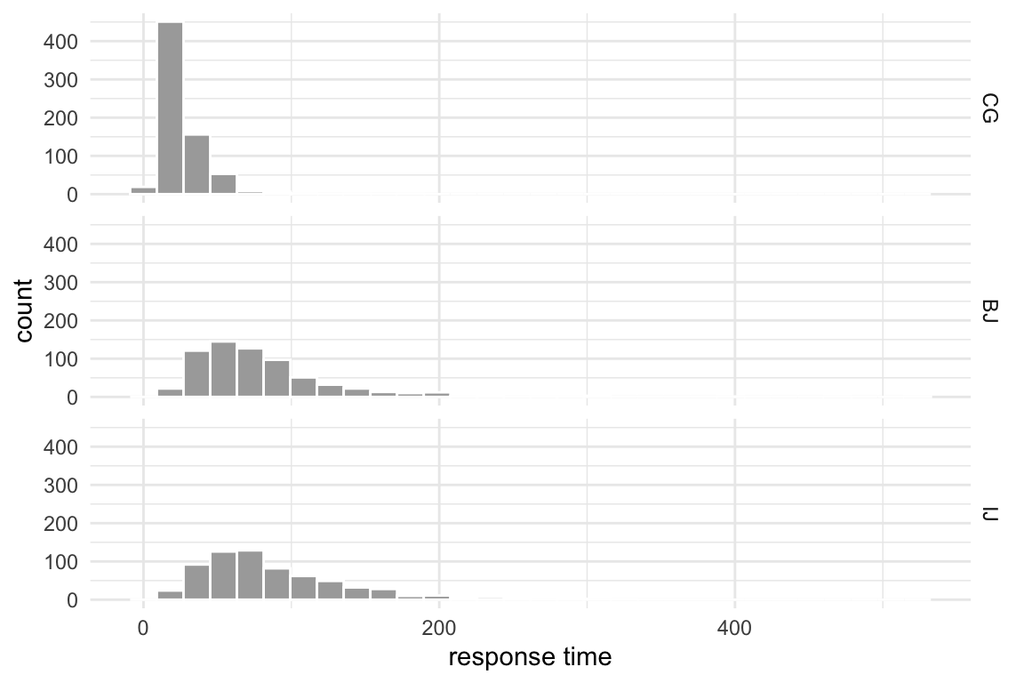

```r
# plot
dag_RT %>%
  ggplot(aes(x=RT)) +
  geom_histogram(fill="darkgrey",color="white")+
  facet_grid(fct_relevel(group, "CG")~.)+
  theme_minimal()+
  labs(x="response time")
```

Both `IJ` and `BJ` conditions exhibit longer response times compared to the control group (`CG`). Numerically, the response time is slightly longer in the `IJ` condition compared to the `BJ` condition, as evidenced by the t-test below.

```r
t.test(log_RT ~ group, dag_RT[dag_RT$group!='CG',])
```

```
##
##  Welch Two Sample t-test
##
## data:  log_RT by group
## t = -3.0785, df = 1337, p-value = 0.002123
## alternative hypothesis: true difference in means between group BJ and group IJ is not equal to 0
## 95 percent confidence interval:
##  -0.15209135 -0.03369816
## sample estimates:
## mean in group BJ mean in group IJ
##         4.245067         4.337962
```

# Perceived effort

There appears to be no difference in the perceived, self-reported effort among the conditions. This is tested formally using an ordinal logistic model.

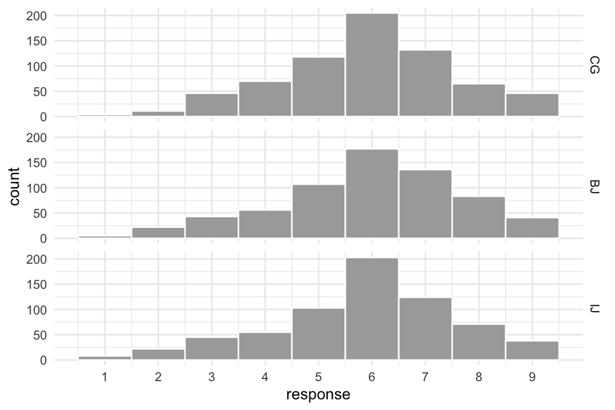

```r
dag_effort <- dat %>%
  group_by(PROLIFIC_PID) %>%
  summarise(CG_mental_effort = mean(CG_mental_effort),
            BJ_mental_effort = mean(BJ_mental_effort),
            IJ_mental_effort = mean(IJ_mental_effort)) %>%
  pivot_longer(cols = ends_with("_mental_effort"),
               names_to = "group",
               values_to = "mental_effort") %>%
  mutate(group = gsub("_mental_effort", "", group),
         group = fct_relevel(group, "CG"))%>%
  filter(!is.na(mental_effort))

# plot
dag_effort %>%
  ggplot(aes(x=mental_effort)) +
  geom_histogram(binwidth=1, fill="darkgrey",color="white")+
  facet_grid(fct_relevel(group, "CG")~.)+
  theme_minimal()+
  scale_x_continuous(breaks=seq(1:9))+
  labs(x="response")
```

```r
# ordinal model
dag_effort$response <- factor(dag_effort$mental_effort)
m_eff <- clm(response ~ group, data = dag_effort)
summary(m_eff)
```

```
## formula: response ~ group
## data:    dag_effort
##
##  link  threshold nobs logLik   AIC     niter max.grad cond.H
##  logit flexible  2036 -3893.41 7806.83 6(0)  3.28e-13 1.2e+02
##
## Coefficients:
##         Estimate Std. Error z value Pr(>|z|)
## groupBJ  0.08065    0.09561   0.844    0.399
## groupIJ -0.01395    0.09519  -0.147    0.883
##
## Threshold coefficients:
##     Estimate Std. Error z value
## 1|2 -4.75600    0.24938 -19.072
## 2|3 -3.28499    0.13128 -25.022
## 3|4 -2.16319    0.09058 -23.882
## 4|5 -1.42845    0.07745 -18.444
## 5|6 -0.59277    0.07068  -8.386
## 6|7  0.59056    0.07092   8.327
## 7|8  1.61549    0.08036  20.104
## 8|9  2.74988    0.10727  25.635
```

```r
tab_model(m_eff, show.r2 = FALSE)
```

|  | response |  |  |
| --- | --- | --- | --- |
| Predictors | Odds Ratios | CI | p |
| 1\|2 | 0.01 | 0.01 – 0.01 | **<0.001** |
| 2\|3 | 0.04 | 0.03 – 0.05 | **<0.001** |
| 3\|4 | 0.11 | 0.10 – 0.14 | **<0.001** |
| 4\|5 | 0.24 | 0.21 – 0.28 | **<0.001** |
| 5\|6 | 0.55 | 0.48 – 0.63 | **<0.001** |
| 6\|7 | 1.80 | 1.57 – 2.07 | **<0.001** |
| 7\|8 | 5.03 | 4.30 – 5.89 | **<0.001** |
| 8\|9 | 15.64 | 12.68 – 19.30 | **<0.001** |
| group [BJ] | 1.08 | 0.90 – 1.31 | 0.399 |
| group [IJ] | 0.99 | 0.82 – 1.19 | 0.883 |
| Observations | 2036 |  |  |

# Beliefs about reviewing justification

The question posed to participants was: *How carefully do you believe the explanations of your answers to the reasoning problems will be reviewed by the research team?*

Participants could choose one of the following options:

1. Not at all reviewed
2. Skimmed
3. Casually reviewed
4. Reviewed with a moderate level of attention
5. Carefully reviewed
6. Extremely carefully reviewed

Most participants reported that they believed their justifications would be reviewed. This belief appears to be slightly stronger in the `IJ` condition.

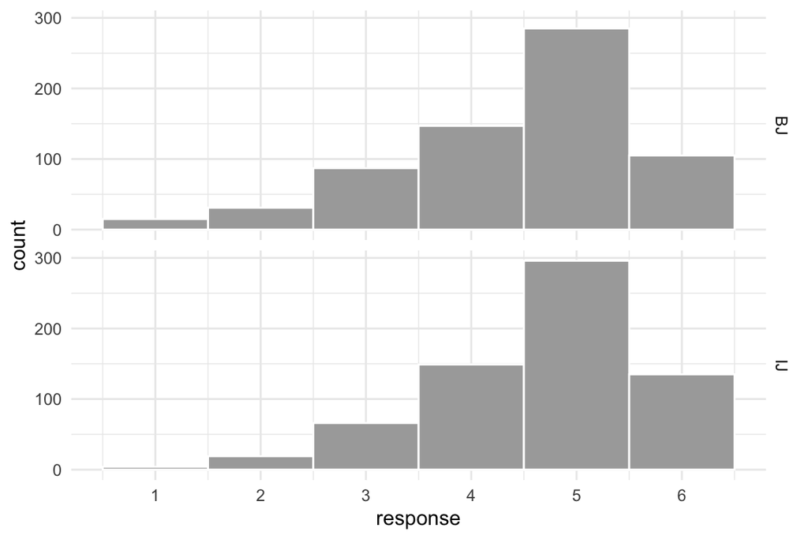

```r
# check review
dag_review <- dat %>%
  group_by(PROLIFIC_PID) %>%
  summarise(BJ_check_review = mean(BJ_check_review),
            IJ_check_review = mean(IJ_check_review)) %>%
  pivot_longer(cols = ends_with("_check_review"),
               names_to = "group",
               values_to = "check_review") %>%
  mutate(group = gsub("_check_review", "", group))%>%
  filter(!is.na(check_review))

# plot
dag_review %>%
  ggplot(aes(x=check_review)) +
  geom_histogram(binwidth=1, fill="darkgrey",color="white")+
  facet_grid(group~.)+
  theme_minimal()+
  scale_x_continuous(breaks=seq(1:6))+
  labs(x="response")
```

To statistically test this difference, we use an ordinal logistic regression model.

```r
# ordinal model
dag_review$response <- factor(dag_review$check_review)
m_review <- clm(response ~ group, data = dag_review)
summary(m_review)
```

```
## formula: response ~ group
## data:    dag_review
##
##  link  threshold nobs logLik   AIC     niter max.grad cond.H
##  logit flexible  1339 -1916.36 3844.72 5(0)  3.42e-07 4.4e+01
##
## Coefficients:
##         Estimate Std. Error z value Pr(>|z|)
## groupIJ   0.3220     0.1001   3.216   0.0013 **
## ---
## Signif. codes:  0 '***' 0.001 '**' 0.01 '*' 0.05 '.' 0.1 ' ' 1
##
## Threshold coefficients:
##     Estimate Std. Error z value
## 1|2 -4.09162    0.23541 -17.381
## 2|3 -2.76121    0.13181 -20.948
## 3|4 -1.46008    0.08742 -16.701
## 4|5 -0.30007    0.07479  -4.012
## 5|6  1.69094    0.08934  18.926
```

```r
tab_model(m_review, show.r2 = FALSE)
```

|  | response |  |  |
| --- | --- | --- | --- |
| Predictors | Odds Ratios | CI | p |
| 1\|2 | 0.02 | 0.01 – 0.03 | **<0.001** |
| 2\|3 | 0.06 | 0.05 – 0.08 | **<0.001** |
| 3\|4 | 0.23 | 0.20 – 0.28 | **<0.001** |
| 4\|5 | 0.74 | 0.64 – 0.86 | **<0.001** |
| 5\|6 | 5.42 | 4.55 – 6.46 | **<0.001** |
| group [IJ] | 1.38 | 1.13 – 1.68 | **0.001** |
| Observations | 1339 |  |  |

# Use of external resources

First, we compute a table indicating the count and fraction of participants reporting the use of external resources for each CRT item.

```r
# ext_resources
dag_resources <- dat %>%
  select(starts_with("ext_resources"),PROLIFIC_PID, group) %>%
  group_by(PROLIFIC_PID, group) %>%
  summarise(ext_resources_use_1 = mean(ext_resources_use_1),
            ext_resources_use_2 = mean(ext_resources_use_2),
            ext_resources_use_3 = mean(ext_resources_use_3),
            ext_resources_use_4 = mean(ext_resources_use_4),
            ext_resources_use_5 = mean(ext_resources_use_5),
            ext_resources_use_6 = mean(ext_resources_use_6)) %>%
  pivot_longer(cols = starts_with("ext_resources"),
               names_to = "CRT",
               values_to = "ext_resources",
               values_drop_na = TRUE) %>%
  filter(!is.na(ext_resources)) %>%
  mutate(CRT = sub(".*_(\\d+)$", "\\1", CRT), # just polish name
         used_external = ifelse(ext_resources==1,1,0))

dag_accuracy <- dat %>%
  mutate(CRT = sub("crt", "", crt)) %>%
  group_by(PROLIFIC_PID, group, CRT) %>%
  summarise(accuracy = mean(accuracy))

dag_resources <- left_join(dag_resources, dag_accuracy, by=c("PROLIFIC_PID", "group", "CRT"))

dag_resources %>%
  group_by(CRT, group) %>%
  summarise(
    proportion = sprintf("%.3f", mean(used_external, na.rm = TRUE)),
    count = sprintf("%i of %i", sum(used_external, na.rm = TRUE), length(used_external))
  )  %>%
  pivot_wider(
    names_from = group,
    values_from = c(proportion, count),
    names_sep = " "
  ) %>%
  knitr::kable(format = "html", booktabs = TRUE, caption = "Proportion and number of people reporting use of external resources for each CRT item.")%>%
  kable_styling(latex_options = c("scale_down","striped"))
```

Proportion and number of people reporting use of external resources for each CRT item.

| CRT | proportion BJ | proportion CG | proportion IJ | count BJ | count CG | count IJ |
| --- | --- | --- | --- | --- | --- | --- |
| 1 | 0.001 | 0.006 | 0.003 | 1 of 670 | 4 of 697 | 2 of 669 |
| 2 | 0.000 | 0.006 | 0.001 | 0 of 670 | 4 of 697 | 1 of 669 |
| 3 | 0.015 | 0.013 | 0.015 | 10 of 670 | 9 of 697 | 10 of 669 |
| 4 | 0.009 | 0.006 | 0.012 | 6 of 670 | 4 of 697 | 8 of 669 |
| 5 | 0.007 | 0.006 | 0.010 | 5 of 670 | 4 of 697 | 7 of 669 |
| 6 | 0.018 | 0.014 | 0.021 | 12 of 670 | 10 of 697 | 14 of 669 |

There appears to be no significant differences in the use of external resources among the groups. This was formally tested using a multilevel logistic regression.

```r
# logistic regression
dag_resources$response <- dag_resources$ext_resources -1
m_res <- glmer(response ~ group + (1|PROLIFIC_PID) + (1|CRT), family=binomial("logit"),data = dag_resources)
summary(m_res)
```

```
## Generalized linear mixed model fit by maximum likelihood (Laplace
##   Approximation) [glmerMod]
##  Family: binomial  ( logit )
## Formula: response ~ group + (1 | PROLIFIC_PID) + (1 | CRT)
##    Data: dag_resources
##
##      AIC      BIC   logLik deviance df.resid
##    688.9    725.9   -339.4    678.9    12211
##
## Scaled residuals:
##     Min      1Q  Median      3Q     Max
## -3.0332  0.0011  0.0023  0.0041  3.5676
##
## Random effects:
##  Groups       Name        Variance Std.Dev.
##  PROLIFIC_PID (Intercept) 117.69   10.848
##  CRT          (Intercept)   1.03    1.015
## Number of obs: 12216, groups:  PROLIFIC_PID, 2036; CRT, 6
##
## Fixed effects:
##             Estimate Std. Error z value Pr(>|z|)
## (Intercept)  13.4618     0.9729  13.837   <2e-16 ***
## groupBJ      -0.2805     0.9834  -0.285    0.775
## groupIJ      -0.3495     0.9712  -0.360    0.719
## ---
## Signif. codes:  0 '***' 0.001 '**' 0.01 '*' 0.05 '.' 0.1 ' ' 1
##
## Correlation of Fixed Effects:
##         (Intr) gropBJ
## groupBJ -0.560
## groupIJ -0.568  0.564
```

```r
tab_model(m_res, show.r2 = FALSE, show.icc = FALSE)
```

|  | response |  |  |
| --- | --- | --- | --- |
| Predictors | Odds Ratios | CI | p |
| (Intercept) | 702079.71 | 104293.95 – 4726217.65 | **<0.001** |
| group [BJ] | 0.76 | 0.11 – 5.19 | 0.775 |
| group [IJ] | 0.71 | 0.11 – 4.73 | 0.719 |
| Random Effects |  |  |  |
| σ<sup>2</sup> | 3.29 |  |  |
| τ<sub>00</sub> <sub>PROLIFIC_PID</sub> | 117.69 |  |  |
| τ<sub>00</sub> <sub>CRT</sub> | 1.03 |  |  |
| N <sub>PROLIFIC_PID</sub> | 2036 |  |  |
| N <sub>CRT</sub> | 6 |  |  |
| Observations | 12216 |  |  |

## Effects of reported use of external resources on accuracy.

We compute the accuracy split by whether participants reported using external resources or not. A logistic model indicates a clear effect of external resource use on accuracy. However, there does not seem to be an interaction effect, suggesting that the presence of response justification does not significantly influence the carefulness or attentiveness with which participants use external resources.

```r
# Compute accuracy by external resource use
dag_resources %>%
  group_by(CRT, group,used_external) %>%
  summarise(
    accuracy = sprintf("%.2f (%.2f)", mean(accuracy, na.rm = TRUE),
                       sd(accuracy, na.rm = TRUE))
  )  %>%
  pivot_wider(
    names_from = group,
    values_from = accuracy,
    names_sep = " "
  ) %>%
  knitr::kable(format = "html", booktabs = TRUE, caption = "Effects of reported use of external resources on accuracy, compute separately for each CRT item. Accuracy here is reported as mean (std.) across participants.")%>%
  kable_styling(latex_options = c("scale_down","striped"))
```

Effects of reported use of external resources on accuracy, compute separately for each CRT item. Accuracy here is reported as mean (std.) across participants.

| CRT | used_external | BJ | CG | IJ |
| --- | --- | --- | --- | --- |
| 1 | 0 | 0.69 (0.46) | 0.67 (0.47) | 0.64 (0.48) |
| 1 | 1 | 1.00 (NA) | 0.25 (0.50) | 0.00 (0.00) |
| 2 | 0 | 0.81 (0.39) | 0.75 (0.43) | 0.77 (0.42) |
| 2 | 1 | NA | 0.75 (0.50) | 0.00 (NA) |
| 3 | 0 | 0.47 (0.50) | 0.34 (0.47) | 0.49 (0.50) |
| 3 | 1 | 0.40 (0.52) | 0.33 (0.50) | 0.70 (0.48) |
| 4 | 0 | 0.64 (0.48) | 0.63 (0.48) | 0.67 (0.47) |
| 4 | 1 | 0.50 (0.55) | 0.75 (0.50) | 0.38 (0.52) |
| 5 | 0 | 0.57 (0.50) | 0.51 (0.50) | 0.60 (0.49) |
| 5 | 1 | 0.80 (0.45) | 0.25 (0.50) | 0.57 (0.53) |
| 6 | 0 | 0.48 (0.50) | 0.36 (0.48) | 0.48 (0.50) |
| 6 | 1 | 0.83 (0.39) | 0.80 (0.42) | 0.86 (0.36) |

```r
# Compute overall accuracy by external resource use
dag_resources %>%
  group_by(PROLIFIC_PID, group,used_external) %>%
  summarise(accuracy = mean(accuracy)) %>%
  group_by(group,used_external) %>%
  summarise(
    accuracy = sprintf("%.2f (%.2f)", mean(accuracy, na.rm = TRUE),
                       sd(accuracy, na.rm = TRUE))
  )  %>%
  pivot_wider(
    names_from = group,
    values_from = accuracy,
    names_sep = " "
  ) %>%
  knitr::kable(format = "html", booktabs = TRUE, caption = "Effects of reported use of external resources on accuracy, compute separately for each CRT item. Accuracy here is reported as mean (std.) across participants.")%>%
  kable_styling(latex_options = c("scale_down","striped"))
```

| used_external | BJ | CG | IJ |
| --- | --- | --- | --- |
| 0 | 0.61 (0.30) | 0.54 (0.29) | 0.61 (0.31) |
| 1 | 0.72 (0.42) | 0.66 (0.43) | 0.75 (0.38) |

```r
# Fit logistic regression model
m_accres <- glmer(accuracy ~ group * used_external + (1|PROLIFIC_PID) + (1|CRT), family=binomial("logit"),data = dag_resources)
summary(m_accres)
```

```
## Generalized linear mixed model fit by maximum likelihood (Laplace
##   Approximation) [glmerMod]
##  Family: binomial  ( logit )
## Formula: accuracy ~ group * used_external + (1 | PROLIFIC_PID) + (1 |      CRT)
##    Data: dag_resources
##
##      AIC      BIC   logLik deviance df.resid
##  14412.8  14472.1  -7198.4  14396.8    12208
##
## Scaled residuals:
##     Min      1Q  Median      3Q     Max
## -3.4321 -0.7044  0.3000  0.5924  2.9380
##
## Random effects:
##  Groups       Name        Variance Std.Dev.
##  PROLIFIC_PID (Intercept) 2.0728   1.4397
##  CRT          (Intercept) 0.5441   0.7376
## Number of obs: 12216, groups:  PROLIFIC_PID, 2036; CRT, 6
##
## Fixed effects:
##                       Estimate Std. Error z value Pr(>|z|)
## (Intercept)            0.24964    0.30843   0.809   0.4183
## groupBJ                0.39654    0.09547   4.154 3.27e-05 ***
## groupIJ                0.39594    0.09565   4.139 3.48e-05 ***
## used_external          1.23682    0.52103   2.374   0.0176 *
## groupBJ:used_external -0.01717    0.71458  -0.024   0.9808
## groupIJ:used_external -0.48522    0.68502  -0.708   0.4787
## ---
## Signif. codes:  0 '***' 0.001 '**' 0.01 '*' 0.05 '.' 0.1 ' ' 1
##
## Correlation of Fixed Effects:
##             (Intr) gropBJ gropIJ usd_xt grBJ:_
## groupBJ     -0.150
## groupIJ     -0.150  0.485
## used_extrnl -0.014  0.049  0.049
## grpBJ:sd_xt  0.010 -0.062 -0.034 -0.726
## grpIJ:sd_xt  0.011 -0.036 -0.069 -0.758  0.553
```

```r
tab_model(m_accres, show.r2 = FALSE, show.icc = FALSE)
```

|  | accuracy |  |  |
| --- | --- | --- | --- |
| Predictors | Odds Ratios | CI | p |
| (Intercept) | 1.28 | 0.70 – 2.35 | 0.418 |
| group [BJ] | 1.49 | 1.23 – 1.79 | **<0.001** |
| group [IJ] | 1.49 | 1.23 – 1.79 | **<0.001** |
| used external | 3.44 | 1.24 – 9.56 | **0.018** |
| group [BJ] × used external | 0.98 | 0.24 – 3.99 | 0.981 |
| group [IJ] × used external | 0.62 | 0.16 – 2.36 | 0.479 |
| Random Effects |  |  |  |
| σ<sup>2</sup> | 3.29 |  |  |
| τ<sub>00</sub> <sub>PROLIFIC_PID</sub> | 2.07 |  |  |
| τ<sub>00</sub> <sub>CRT</sub> | 0.54 |  |  |
| N <sub>PROLIFIC_PID</sub> | 2036 |  |  |
| N <sub>CRT</sub> | 6 |  |  |
| Observations | 12216 |  |  |

# Familiarity

The question posed to participants was: *Have you ever encountered any of the reasoning problems listed below before participating in our study?*

Response options:

1. yes, I did encounter the same problem before
2. yes, I did encounter a very similar problem before
3. no, I have not encountered it before

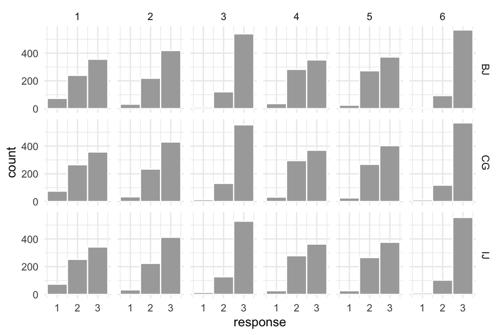

facets 1 to 6 indicate the different CRT problems

```r
dag_fam <- dat %>%
  select(starts_with("familiarity"),PROLIFIC_PID, group) %>%
  group_by(PROLIFIC_PID, group) %>%
  summarise(familiarity_1 = mean(familiarity_1),
            familiarity_2 = mean(familiarity_2),
            familiarity_3 = mean(familiarity_3),
            familiarity_4 = mean(familiarity_4),
            familiarity_5 = mean(familiarity_5),
            familiarity_6 = mean(familiarity_6)) %>%
  pivot_longer(cols = starts_with("familiarity"),
               names_to = "CRT",
               values_to = "familiarity",
               values_drop_na = TRUE) %>%
  filter(!is.na(familiarity)) %>%
  mutate(CRT = sub(".*_(\\d+)$", "\\1", CRT))

dag_accuracy <- dat %>%
  mutate(CRT = sub("crt", "", crt)) %>%
  group_by(PROLIFIC_PID, group, CRT) %>%
  summarise(accuracy = mean(accuracy))

dag_fam <- left_join(dag_fam, dag_accuracy, by=c("PROLIFIC_PID", "group", "CRT"))

# plot
dag_fam %>%
  ggplot(aes(x=familiarity)) +
  geom_histogram(binwidth=1, fill="darkgrey",color="white")+
  facet_grid(group~CRT)+
  theme_minimal()+
  scale_x_continuous(breaks=seq(1:3))+
  labs(x="response")
```

To analyze the differences in familiarity, we use an ordinal logistic model.

```r
# ordinal logistic model
dag_fam$response <- factor(dag_fam$familiarity)
dag_fam$CRT <- factor(dag_fam$CRT)
m_fam <- clm(response ~ group + CRT, data = dag_fam)
summary(m_fam)
```

```
## formula: response ~ group + CRT
## data:    dag_fam
##
##  link  threshold nobs  logLik   AIC      niter max.grad cond.H
##  logit flexible  12216 -9189.16 18396.32 6(0)  6.07e-12 5.9e+01
##
## Coefficients:
##         Estimate Std. Error z value Pr(>|z|)
## groupBJ 0.029324   0.047024   0.624  0.53289
## groupIJ 0.004619   0.046939   0.098  0.92161
## CRT2    0.485530   0.062921   7.717 1.20e-14 ***
## CRT3    1.365354   0.070326  19.415  < 2e-16 ***
## CRT4    0.166812   0.061461   2.714  0.00665 **
## CRT5    0.299159   0.061845   4.837 1.32e-06 ***
## CRT6    1.586540   0.073521  21.579  < 2e-16 ***
## ---
## Signif. codes:  0 '***' 0.001 '**' 0.01 '*' 0.05 '.' 0.1 ' ' 1
##
## Threshold coefficients:
##     Estimate Std. Error z value
## 1|2 -2.51035    0.06313 -39.767
## 2|3  0.01453    0.05155   0.282
```

```r
tab_model(m_fam, show.r2 = FALSE)
```

|  | response |  |  |
| --- | --- | --- | --- |
| Predictors | Odds Ratios | CI | p |
| 1\|2 | 0.08 | 0.07 – 0.09 | **<0.001** |
| 2\|3 | 1.01 | 0.92 – 1.12 | 0.778 |
| group [BJ] | 1.03 | 0.94 – 1.13 | 0.533 |
| group [IJ] | 1.00 | 0.92 – 1.10 | 0.922 |
| CRT [2] | 1.63 | 1.44 – 1.84 | **<0.001** |
| CRT [3] | 3.92 | 3.41 – 4.50 | **<0.001** |
| CRT [4] | 1.18 | 1.05 – 1.33 | **0.007** |
| CRT [5] | 1.35 | 1.19 – 1.52 | **<0.001** |
| CRT [6] | 4.89 | 4.23 – 5.64 | **<0.001** |
| Observations | 12216 |  |  |

### Familiarity: overall counts and proportion of responses

```r
# count the occurrences of each rating
familiarity_counts <- dag_fam %>%
  group_by(familiarity) %>%
  summarise(count = n()) %>%
  ungroup()

# total number of ratings
total_ratings <- sum(familiarity_counts$count)

# percentage for each familiarity rating
familiarity_counts <- familiarity_counts %>%
  mutate(percentage = sprintf("%.2f %s", (count / total_ratings) * 100, " %"))

# display the table
familiarity_counts %>%
  knitr::kable(format = "html", booktabs = TRUE, caption = "Familiarity (counts summed across all CRT problems)")%>%
  kable_styling(latex_options = c("scale_down","striped"))
```

Familiarity (counts summed across all CRT problems)

| familiarity | count | percentage |
| --- | --- | --- |
| 1 | 564 | 4.62 % |
| 2 | 3793 | 31.05 % |
| 3 | 7859 | 64.33 % |

## Effects of familiarity on accuracy

We examined how accuracy changed with reported familiarity. Data provide evidence that accuracy is higher with greater familiarity.

We also tested whether the effect of familiarity interacted with the effect of response justification. There is some evidence for an interaction, potentially due to a ceiling effect. Essentially, the effect of familiarity is larger than the effect of response justification, and the accuracy in CRT problems that are familiar to participants is already high, which seems to attenuate the effect of asking for response justification.

```r
# Compute accuracy split by familiarity
dag_fam %>%
  group_by(group,familiarity, CRT) %>%
  summarise(
    accuracy = sprintf("%.2f (%.2f)", mean(accuracy, na.rm = TRUE),
                       sd(accuracy, na.rm = TRUE))
  )  %>%
  pivot_wider(
    names_from = group,
    values_from = accuracy,
    names_sep = " "
  ) %>%
  knitr::kable(format = "html", booktabs = TRUE, caption = "Accuracy split by familiarity.")%>%
  kable_styling(latex_options = c("scale_down","striped"))
```

Accuracy split by familiarity.

| familiarity | CRT | BJ | CG | IJ |
| --- | --- | --- | --- | --- |
| 1 | 1 | 0.93 (0.25) | 0.93 (0.25) | 0.97 (0.16) |
| 1 | 2 | 0.91 (0.30) | 0.91 (0.29) | 0.97 (0.17) |
| 1 | 3 | 0.80 (0.42) | 0.54 (0.52) | 0.57 (0.51) |
| 1 | 4 | 0.78 (0.42) | 0.66 (0.48) | 0.81 (0.40) |
| 1 | 5 | 0.92 (0.28) | 0.81 (0.40) | 0.70 (0.47) |
| 1 | 6 | 0.67 (0.50) | 0.50 (0.52) | 0.64 (0.50) |
| 2 | 1 | 0.89 (0.32) | 0.89 (0.32) | 0.88 (0.33) |
| 2 | 2 | 0.96 (0.20) | 0.91 (0.29) | 0.92 (0.27) |
| 2 | 3 | 0.58 (0.50) | 0.53 (0.50) | 0.64 (0.48) |
| 2 | 4 | 0.78 (0.41) | 0.79 (0.41) | 0.82 (0.38) |
| 2 | 5 | 0.80 (0.40) | 0.80 (0.40) | 0.86 (0.34) |
| 2 | 6 | 0.54 (0.50) | 0.56 (0.50) | 0.62 (0.49) |
| 3 | 1 | 0.50 (0.50) | 0.45 (0.50) | 0.39 (0.49) |
| 3 | 2 | 0.73 (0.45) | 0.66 (0.48) | 0.67 (0.47) |
| 3 | 3 | 0.43 (0.50) | 0.29 (0.45) | 0.45 (0.50) |
| 3 | 4 | 0.50 (0.50) | 0.51 (0.50) | 0.54 (0.50) |
| 3 | 5 | 0.38 (0.49) | 0.30 (0.46) | 0.40 (0.49) |
| 3 | 6 | 0.48 (0.50) | 0.32 (0.47) | 0.46 (0.50) |

```r
# Compute overall accuracy split by familiarity
dag_fam %>%
  group_by(group,familiarity) %>%
  summarise(
    accuracy = sprintf("%.2f (%.2f)", mean(accuracy, na.rm = TRUE),
                       sd(accuracy, na.rm = TRUE))
  )  %>%
  pivot_wider(
    names_from = group,
    values_from = accuracy,
    names_sep = " "
  ) %>%
  knitr::kable(format = "html", booktabs = TRUE, caption = "Accuracy split by familiarity.")%>%
  kable_styling(latex_options = c("scale_down","striped"))
```

Accuracy split by familiarity.

| familiarity | BJ | CG | IJ |
| --- | --- | --- | --- |
| 1 | 0.88 (0.33) | 0.81 (0.39) | 0.86 (0.35) |
| 2 | 0.80 (0.40) | 0.78 (0.41) | 0.82 (0.38) |
| 3 | 0.50 (0.50) | 0.41 (0.49) | 0.49 (0.50) |

```r
# Fit logistic regression model
dag_fam$familiarity <- factor(dag_fam$familiarity)
contrasts(dag_fam$familiarity) <- contr.treatment(levels(dag_fam$familiarity), base=3) # this ensure main effect of conditions is tested at familiarity = 3
m_fam <- glmer(accuracy ~ group * familiarity + (1|PROLIFIC_PID) + (1|CRT), family=binomial("logit"),data = dag_fam, control=glmerControl(optimizer="bobyqa"))
summary(m_fam)
```

```
## Generalized linear mixed model fit by maximum likelihood (Laplace
##   Approximation) [glmerMod]
##  Family: binomial  ( logit )
## Formula: accuracy ~ group * familiarity + (1 | PROLIFIC_PID) + (1 | CRT)
##    Data: dag_fam
## Control: glmerControl(optimizer = "bobyqa")
##
##      AIC      BIC   logLik deviance df.resid
##  13576.5  13658.0  -6777.3  13554.5    12205
##
## Scaled residuals:
##     Min      1Q  Median      3Q     Max
## -4.8189 -0.6227  0.2555  0.5804  3.4180
##
## Random effects:
##  Groups       Name        Variance Std.Dev.
##  PROLIFIC_PID (Intercept) 1.7212   1.3119
##  CRT          (Intercept) 0.3913   0.6256
## Number of obs: 12216, groups:  PROLIFIC_PID, 2036; CRT, 6
##
## Fixed effects:
##                      Estimate Std. Error z value Pr(>|z|)
## (Intercept)          -0.39909    0.26515  -1.505   0.1323
## groupBJ               0.53436    0.10151   5.264 1.41e-07 ***
## groupIJ               0.46861    0.10191   4.598 4.26e-06 ***
## familiarity1          2.51013    0.26564   9.449  < 2e-16 ***
## familiarity2          1.93831    0.11247  17.234  < 2e-16 ***
## groupBJ:familiarity1 -0.21688    0.38881  -0.558   0.5770
## groupIJ:familiarity1 -0.07418    0.39670  -0.187   0.8517
## groupBJ:familiarity2 -0.40159    0.15885  -2.528   0.0115 *
## groupIJ:familiarity2 -0.18097    0.16203  -1.117   0.2640
## ---
## Signif. codes:  0 '***' 0.001 '**' 0.01 '*' 0.05 '.' 0.1 ' ' 1
##
## Correlation of Fixed Effects:
##             (Intr) gropBJ gropIJ fmlrt1 fmlrt2 grBJ:1 grIJ:1 grBJ:2
## groupBJ     -0.189
## groupIJ     -0.188  0.494
## familiarty1 -0.052  0.136  0.135
## familiarty2 -0.116  0.299  0.298  0.158
## grpBJ:fmlr1  0.034 -0.175 -0.089 -0.670 -0.094
## grpIJ:fmlr1  0.033 -0.087 -0.179 -0.653 -0.089  0.446
## grpBJ:fmlr2  0.079 -0.416 -0.208 -0.097 -0.685  0.138  0.064
## grpIJ:fmlr2  0.078 -0.205 -0.414 -0.095 -0.673  0.064  0.129  0.475
```

```r
tab_model(m_fam, show.r2 = FALSE, show.icc = FALSE)
```

|  | accuracy |  |  |
| --- | --- | --- | --- |
| Predictors | Odds Ratios | CI | p |
| (Intercept) | 0.67 | 0.40 – 1.13 | 0.132 |
| group [BJ] | 1.71 | 1.40 – 2.08 | **<0.001** |
| group [IJ] | 1.60 | 1.31 – 1.95 | **<0.001** |
| familiarity [1] | 12.31 | 7.31 – 20.71 | **<0.001** |
| familiarity [2] | 6.95 | 5.57 – 8.66 | **<0.001** |
| group [BJ] × familiarity [1] | 0.81 | 0.38 – 1.72 | 0.577 |
| group [IJ] × familiarity [1] | 0.93 | 0.43 – 2.02 | 0.852 |
| group [BJ] × familiarity [2] | 0.67 | 0.49 – 0.91 | **0.011** |
| group [IJ] × familiarity [2] | 0.83 | 0.61 – 1.15 | 0.264 |
| Random Effects |  |  |  |
| σ<sup>2</sup> | 3.29 |  |  |
| τ<sub>00</sub> <sub>PROLIFIC_PID</sub> | 1.72 |  |  |
| τ<sub>00</sub> <sub>CRT</sub> | 0.39 |  |  |
| N <sub>PROLIFIC_PID</sub> | 2036 |  |  |
| N <sub>CRT</sub> | 6 |  |  |
| Observations | 12216 |  |  |